# (노트) 인자분석 - FIFA 축구선수 능력치

Jul 1, 2021 • 신록예찬 • 10 min read

응용통계

- About this doc
- Data
- 고유값
- 스크리 그림
- I. 인자회전 (인자수: 5개)
  - h2
  - SS lodings
  - Proportion Var, Cumulative Var
  - RC1, RC3, RC2, RC4, RC5
- II. 인자회전 (인자수: 3개)
  - RC1, RC3, RC2
- 행렬도

### About this doc

`-` 인자분석 예제: FIFA 축구선수 능력치

`-` 데이터 출처: https://www.kaggle.com/bryanb/fifa-player-stats-database?select=FIFA21_official_data.csv

### Data

`-` 아래의 자료는 유명한 비디오 게임이 제공하는 축구선수들의 능력치에 대한 자료이다.

```python
import rpy2
%load_ext rpy2.ipython
```

```python
%%R
library(tidyverse)
fifa_dat=read_csv('2021-07-01-fifa.csv')
```

```python
%%R
head(fifa_dat)
```

```
# A tibble: 6 x 33
  Crossing Finishing HeadingAccuracy ShortPassing Volleys Dribbling Curve
     <dbl>     <dbl>           <dbl>        <dbl>   <dbl>     <dbl> <dbl>
1       80        92              84           83      90        84    86
2       94        82              55           94      82        88    85
3       87        77              58           88      86        85    86
4       83        88              83           84      87        87    86
5       87        66              57           81      68        87    88
6       89        65              67           83      67        82    87
# … with 26 more variables: FKAccuracy <dbl>, LongPassing <dbl>,
#   BallControl <dbl>, Acceleration <dbl>, SprintSpeed <dbl>, Agility <dbl>,
#   Reactions <dbl>, Balance <dbl>, ShotPower <dbl>, Jumping <dbl>,
#   Stamina <dbl>, Strength <dbl>, LongShots <dbl>, Aggression <dbl>,
#   Interceptions <dbl>, Positioning <dbl>, Vision <dbl>, Penalties <dbl>,
#   Composure <dbl>, StandingTackle <dbl>, SlidingTackle <dbl>, GKDiving <dbl>,
#   GKHandling <dbl>, GKKicking <dbl>, GKPositioning <dbl>, GKReflexes <dbl>
```

`-` 데이터는 캐글의 FIFA21 OFFICIAL DATASET 을 활용하였다.

- 출처: https://www.kaggle.com/bryanb/fifa-player-stats-database?select=FIFA21_official_data.csv

`-` 문제의 분석을 위하여 선수의 능력치와 관련없는 일부변수는 제외하였으며 (이름, 얼굴사진 등) 정리된 자료는 아래에서 다운받을 수 있다.

- https://github.com/miruetoto/yechan/blob/master/_notebooks/2021-07-01-fifa.csv

`-` 자료구조

- $n$: 16821 player
- $p$: 33 variable

`-` 각 변수들은 축구선수들의 능력치와 관련되어 있으며 구체적인 목록은 아래와 같다.

```python
%%R
names(fifa_dat)
```

```
 [1] "Crossing"        "Finishing"       "HeadingAccuracy" "ShortPassing"
 [5] "Volleys"         "Dribbling"       "Curve"           "FKAccuracy"
 [9] "LongPassing"     "BallControl"     "Acceleration"    "SprintSpeed"
[13] "Agility"         "Reactions"       "Balance"         "ShotPower"
[17] "Jumping"         "Stamina"         "Strength"        "LongShots"
[21] "Aggression"      "Interceptions"   "Positioning"     "Vision"
[25] "Penalties"       "Composure"       "StandingTackle"  "SlidingTackle"
[29] "GKDiving"        "GKHandling"      "GKKicking"       "GKPositioning"
[33] "GKReflexes"
```

### 고유값

```python
%%R
library(psych)
fifa_factor=principal(fifa_dat,rotate='none')
fifa_factor$values
```

```
 [1] 17.87966149  4.54274240  2.94590728  1.79041155  1.36780887  0.60224284
 [7]  0.44224002  0.33838567  0.31283176  0.28427022  0.25838792  0.23860340
[13]  0.20710617  0.19496595  0.18922822  0.17197376  0.15497700  0.13182625
[19]  0.12808383  0.11847152  0.10326586  0.09009330  0.07669736  0.06474389
[25]  0.06193828  0.06017035  0.05631684  0.03771976  0.03423692  0.03235278
[31]  0.03188949  0.02812511  0.02232395
```

`-` 5번째 인자까지 고유값이 1이상인 것을 알 수 있다.

### 스크리 그림

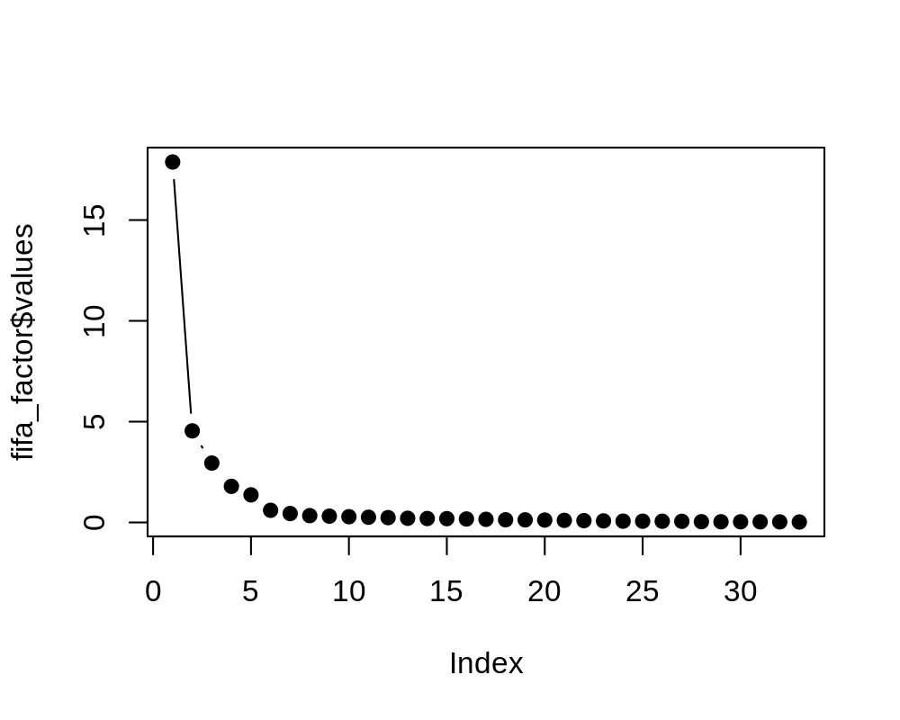

```python
%%R -w 1000 -h 800 -r 200
plot(fifa_factor$values,type='b',pch=19)
```

`-` 유효한 인자수는 5개정도로 보자.

### I. 인자회전 (인자수: 5개)

`-` 본 예제에서는 직교회전의 varimax을 사용하였다.

```python
%%R
fifa_varimax = principal(fifa_dat,nfactors=5,rotate="varimax")
fifa_varimax
```

```
Principal Components Analysis
Call: principal(r = fifa_dat, nfactors = 5, rotate = "varimax")
Standardized loadings (pattern matrix) based upon correlation matrix
                  RC1   RC3   RC2   RC4   RC5   h2    u2 com
Crossing         0.64  0.31  0.35  0.44 -0.08 0.83 0.170 3.0
Finishing        0.79  0.42 -0.22  0.26  0.08 0.92 0.078 2.0
HeadingAccuracy  0.31  0.64  0.33 -0.08  0.50 0.87 0.126 3.0
ShortPassing     0.68  0.38  0.48  0.24  0.07 0.89 0.106 2.8
Volleys          0.82  0.39 -0.11  0.21  0.09 0.88 0.118 1.7
Dribbling        0.69  0.47  0.17  0.45  0.01 0.93 0.074 2.7
Curve            0.79  0.29  0.18  0.32 -0.08 0.85 0.147 1.8
FKAccuracy       0.79  0.25  0.20  0.20 -0.14 0.78 0.217 1.6
LongPassing      0.64  0.19  0.60  0.18 -0.04 0.84 0.156 2.3
BallControl      0.70  0.49  0.29  0.34  0.08 0.93 0.073 2.7
Acceleration     0.29  0.33  0.00  0.83  0.09 0.89 0.107 1.6
SprintSpeed      0.25  0.36  0.00  0.78  0.18 0.84 0.159 1.8
Agility          0.46  0.19  0.04  0.79 -0.02 0.87 0.134 1.8
Reactions        0.63 -0.32  0.33  0.02  0.42 0.78 0.215 2.9
Balance          0.35  0.19  0.11  0.76 -0.18 0.78 0.221 1.7
ShotPower        0.86  0.06 -0.06  0.03  0.18 0.79 0.211 1.1
Jumping         -0.03  0.01  0.17  0.24  0.78 0.69 0.307 1.3
Stamina          0.36  0.38  0.44  0.41  0.32 0.74 0.263 4.8
Strength         0.09  0.12  0.21 -0.45  0.71 0.78 0.224 2.0
LongShots        0.85  0.35  0.02  0.23  0.06 0.90 0.105 1.5
Aggression       0.27  0.34  0.66 -0.02  0.41 0.78 0.216 2.7
Interceptions    0.05  0.19  0.93  0.01  0.16 0.93 0.067 1.1
Positioning      0.75  0.44  0.00  0.36  0.08 0.89 0.107 2.1
Vision           0.85 -0.01  0.16  0.25 -0.07 0.82 0.182 1.3
Penalties        0.76  0.46 -0.10  0.15  0.10 0.82 0.177 1.8
Composure        0.75  0.05  0.34  0.09  0.29 0.77 0.226 1.8
StandingTackle   0.01  0.26  0.93  0.02  0.11 0.95 0.048 1.2
SlidingTackle   -0.04  0.25  0.93  0.03  0.10 0.95 0.054 1.2
GKDiving        -0.27 -0.86 -0.29 -0.26 -0.03 0.97 0.035 1.7
GKHandling      -0.27 -0.86 -0.29 -0.26 -0.03 0.96 0.037 1.7
GKKicking       -0.27 -0.86 -0.29 -0.26 -0.03 0.96 0.043 1.7
GKPositioning   -0.27 -0.86 -0.28 -0.26 -0.02 0.96 0.037 1.6
GKReflexes      -0.27 -0.86 -0.29 -0.26 -0.03 0.97 0.034 1.7

                        RC1  RC3  RC2  RC4  RC5
SS loadings           10.24 6.69 5.06 4.41 2.12
Proportion Var         0.31 0.20 0.15 0.13 0.06
Cumulative Var         0.31 0.51 0.67 0.80 0.86
Proportion Explained   0.36 0.23 0.18 0.15 0.07
Cumulative Proportion  0.36 0.59 0.77 0.93 1.00

Mean item complexity =  2
Test of the hypothesis that 5 components are sufficient.

The root mean square of the residuals (RMSR) is  0.02
 with the empirical chi square  7565.01  with prob <  0
 FALSE
Fit based upon off diagonal values = 1
```

#### h2

`-` h2는 각 변수들이 유의한 다섯개의 인자 RC1,...,RC5에 의하여 설명되어지는 부분의 비율인 공통성을 나타내며, 위의 인자부하값을 이용하여 다음과 같이 구해진다.

- Crossing : $0.83=0.64^2+0.31^2+0.35^2+0.44^2+(-0.08)^2$
- Finishing : $0.92=0.79^2+0.42^2+(-0.22)^2+0.26^2+(0.08)^2$
- ...

`-` 공통성이 많은 변수중에서 서로 연관이 있는 일부 변수들을 선택하기 위해서 인자분석을 실시하는 경우 변수선택의 기준으로 이용할 수 있다. 예를들어 위의 예제 Jumping의 경우 공통성을 나타내는 지표인 h2가 0.69으로 다른 변수들보다 상대적으로 낮은데 이는 Jumping이 다른 변수들과 공통점이 별로 없는 것으로 판단 할 수 있다.

`-` u2=1-h2는 고유분산을 의미한다.

#### SS lodings

`-` SS lodings은 각 인자에 의해 설명되는 분산의 양을 나타낸다. 이는 인자 부하값의 제곱의 합으로 다음과 같이 구해진다.

- RC1: $10.24 = 0.64^2+0.79^2+ \dots + (-0.27)^2$
- RC3: $6.69 = 0.31^2+0.42^2+ \dots + (-0.86)^2$
- ...

#### Proportion Var, Cumulative Var

`-` Proportion Var와 Cumulative Var는 각 각 인자가 설명하는 총분산의 비율과 그 누적값을 의미한다.

`-` RC1이 총 분산의 31%, RC3이 총 분산의 20%를 설명한다.

`-` RC1, RC3, RC2, RC4 에 의하여 설명되는 변동은 총 변동의 80%이다.

#### RC1, RC3, RC2, RC4, RC5

`-` RC1은 Finishing, Volleys, Curve, FKAccuracy, BallControl, ShotPower, LongShots, Positioning, Vision, Penalties, Composure 가 높은 값을 가진다. 따라서 이 인자는 스트라이커 혹은 공격형 미드필터가 필요로 하는 능력치로 해석할 수 있다.

```python
%%R
fifa_varimax$loadings[,1]
```

```
       Crossing       Finishing HeadingAccuracy    ShortPassing         Volleys
    0.637414357     0.789351141     0.314495690     0.679312050     0.817184293
      Dribbling           Curve      FKAccuracy     LongPassing     BallControl
    0.692339194     0.793309064     0.787869456     0.640837523     0.699742170
   Acceleration     SprintSpeed         Agility       Reactions         Balance
    0.285434185     0.254968288     0.459628451     0.627043368     0.345772217
      ShotPower         Jumping         Stamina        Strength       LongShots
    0.864972507    -0.027310685     0.357176146     0.094780306     0.846494679
     Aggression   Interceptions     Positioning          Vision       Penalties
    0.273190265     0.050081960     0.752984594     0.853045973     0.756603398
      Composure  StandingTackle   SlidingTackle        GKDiving      GKHandling
    0.748901773     0.007312332    -0.037213362    -0.273567738    -0.273606418
      GKKicking   GKPositioning      GKReflexes
   -0.268855488    -0.268990694    -0.274351648
```

```python
%%R
fifa_varimax$loadings[,3]
```

```
       Crossing       Finishing HeadingAccuracy    ShortPassing         Volleys
   0.3545081595   -0.2161529958    0.3307642513    0.4752724169   -0.1112193429
      Dribbling           Curve      FKAccuracy     LongPassing     BallControl
   0.1705703476    0.1751259500    0.2002665071    0.6026588521    0.2856359932
   Acceleration     SprintSpeed         Agility       Reactions         Balance
   0.0032365752   -0.0001120553    0.0407499359    0.3273344278    0.1058226056
      ShotPower         Jumping         Stamina        Strength       LongShots
  -0.0576638663    0.1731688062    0.4429347162    0.2117825446    0.0153585077
     Aggression   Interceptions     Positioning          Vision       Penalties
   0.6571972702    0.9323630320   -0.0030276636    0.1552658643   -0.1007701795
      Composure  StandingTackle   SlidingTackle        GKDiving      GKHandling
   0.3409204839    0.9333718619    0.9343377299   -0.2863346939   -0.2854453599
      GKKicking   GKPositioning      GKReflexes
  -0.2871439316   -0.2838572412   -0.2883841591
```

```python
%%R
fifa_varimax$loadings[,2]
```

```
       Crossing       Finishing HeadingAccuracy    ShortPassing         Volleys
     0.31214662      0.41933383      0.64246521      0.37776058      0.38819034
      Dribbling           Curve      FKAccuracy     LongPassing     BallControl
     0.46840877      0.28684346      0.24859071      0.19411924      0.48552810
   Acceleration     SprintSpeed         Agility       Reactions         Balance
     0.32707849      0.36363065      0.18845608     -0.32485924      0.19371315
      ShotPower         Jumping         Stamina        Strength       LongShots
     0.05637016      0.01232201      0.38219661      0.12138102      0.35085321
     Aggression   Interceptions     Positioning          Vision       Penalties
     0.33640174      0.19011315      0.43766528     -0.01085578      0.45721170
      Composure  StandingTackle   SlidingTackle        GKDiving      GKHandling
     0.04806416      0.26173005      0.24704362     -0.85919118     -0.85834341
      GKKicking   GKPositioning      GKReflexes
    -0.85551172     -0.86042638     -0.85888156
```

`-` RC4는 Acceleration, SprintSpeed, Agility, Balance 에서 큰 값을 가진다. 따라서 이는 순발력 혹은 민첩성과 관련된 인자로 해석할 수 있다.

```python
%%R
fifa_varimax$loadings[,4]
```

```
       Crossing       Finishing HeadingAccuracy    ShortPassing         Volleys
     0.44057834      0.26335492     -0.08163892      0.24192353      0.20853217
      Dribbling           Curve      FKAccuracy     LongPassing     BallControl
     0.44533963      0.32323559      0.20349375      0.17510236      0.33754539
   Acceleration     SprintSpeed         Agility       Reactions         Balance
     0.83479909      0.78242186      0.78551196      0.02111821      0.76059085
      ShotPower         Jumping         Stamina        Strength       LongShots
     0.03130795      0.23549487      0.40600573     -0.45464984      0.22903278
     Aggression   Interceptions     Positioning          Vision       Penalties
    -0.02067596      0.01054005      0.35901878      0.24666333      0.14701104
      Composure  StandingTackle   SlidingTackle        GKDiving      GKHandling
     0.09322065      0.02008380      0.03431326     -0.26305565     -0.26354954
      GKKicking   GKPositioning      GKReflexes
    -0.26388148     -0.26288638     -0.26248381
```

`-` RC5는 Jumping, Strength에서 큰 적재값을 가지며 이는 신체능력과 관련있는 인자로 해석할 수 있다.

```python
%%R
fifa_varimax$loadings[,5]
```

```
       Crossing       Finishing HeadingAccuracy    ShortPassing         Volleys
   -0.082976003     0.080839801     0.495947178     0.070290604     0.089382762
      Dribbling           Curve      FKAccuracy     LongPassing     BallControl
    0.006070171    -0.077326337    -0.137298742    -0.038434013     0.080584043
   Acceleration     SprintSpeed         Agility       Reactions         Balance
    0.090098167     0.177523057    -0.018781684     0.422364652    -0.178574515
      ShotPower         Jumping         Stamina        Strength       LongShots
    0.182561678     0.778857141     0.320509049     0.707282496     0.055360153
     Aggression   Interceptions     Positioning          Vision       Penalties
    0.405419727     0.158884237     0.076117981    -0.073452295     0.098902412
      Composure  StandingTackle   SlidingTackle        GKDiving      GKHandling
    0.293462931     0.109464396     0.095097385    -0.027687606    -0.028919699
      GKKicking   GKPositioning      GKReflexes
   -0.029883097    -0.021725312    -0.025407702
```

`-` RC1,2,3 정도로도 자료를 충분히 설명할 수 있어보인다.

### II. 인자회전 (인자수: 3개)

`-` 인자수를 3개로 수정하여 보자.

```python
%%R
fifa_varimax2 = principal(fifa_dat,nfactors=3,rotate="varimax")
fifa_varimax2
```

```
Principal Components Analysis
Call: principal(r = fifa_dat, nfactors = 3, rotate = "varimax")
Standardized loadings (pattern matrix) based upon correlation matrix
                  RC3   RC1   RC2   h2    u2 com
Crossing         0.62  0.56  0.26 0.76 0.238 2.3
Finishing        0.79  0.47 -0.09 0.85 0.145 1.7
HeadingAccuracy  0.29  0.39  0.66 0.66 0.337 2.0
ShortPassing     0.64  0.47  0.49 0.87 0.128 2.7
Volleys          0.81  0.42  0.01 0.83 0.170 1.5
Dribbling        0.68  0.65  0.17 0.92 0.076 2.1
Curve            0.77  0.46  0.14 0.82 0.176 1.7
FKAccuracy       0.74  0.37  0.15 0.71 0.285 1.6
LongPassing      0.59  0.32  0.52 0.73 0.274 2.5
BallControl      0.68  0.60  0.33 0.93 0.074 2.4
Acceleration     0.38  0.73 -0.08 0.68 0.318 1.5
SprintSpeed      0.35  0.71 -0.03 0.63 0.373 1.5
Agility          0.53  0.62 -0.10 0.68 0.317 2.0
Reactions        0.68 -0.29  0.41 0.72 0.281 2.0
Balance          0.39  0.64 -0.11 0.58 0.417 1.7
ShotPower        0.87  0.04  0.07 0.76 0.236 1.0
Jumping          0.10  0.00  0.41 0.18 0.820 1.1
Stamina          0.39  0.51  0.51 0.67 0.332 2.9
Strength         0.10 -0.29  0.61 0.47 0.529 1.5
LongShots        0.83  0.42  0.09 0.87 0.125 1.5
Aggression       0.25  0.22  0.82 0.78 0.224 1.3
Interceptions    0.00  0.18  0.90 0.84 0.158 1.1
Positioning      0.75  0.56  0.07 0.88 0.119 1.9
Vision           0.85  0.18  0.08 0.76 0.242 1.1
Penalties        0.73  0.44  0.05 0.73 0.267 1.6
Composure        0.76  0.07  0.43 0.77 0.230 1.6
StandingTackle  -0.05  0.26  0.89 0.86 0.139 1.2
SlidingTackle   -0.09  0.25  0.88 0.84 0.158 1.2
GKDiving        -0.21 -0.85 -0.39 0.91 0.087 1.5
GKHandling      -0.21 -0.85 -0.39 0.91 0.088 1.5
GKKicking       -0.21 -0.85 -0.39 0.91 0.093 1.5
GKPositioning   -0.21 -0.85 -0.38 0.91 0.089 1.5
GKReflexes      -0.21 -0.85 -0.39 0.91 0.086 1.5

                        RC3  RC1  RC2
SS loadings           10.08 9.11 6.18
Proportion Var         0.31 0.28 0.19
Cumulative Var         0.31 0.58 0.77
Proportion Explained   0.40 0.36 0.24
Cumulative Proportion  0.40 0.76 1.00

Mean item complexity =  1.7
Test of the hypothesis that 3 components are sufficient.

The root mean square of the residuals (RMSR) is  0.06
 with the empirical chi square  63865.89  with prob <  0
 FALSE
Fit based upon off diagonal values = 0.99
```

`-` 3개의 인자를 사용해도 총변동의 77%를 설명하므로 3개의 인자도 적당해보인다.

#### RC1, RC3, RC2

`-` RC1, RC2, RC3 에 대한 해석도 동일하다.

```python
%%R
fifa_varimax$loadings[,1]
```

```
       Crossing       Finishing HeadingAccuracy    ShortPassing         Volleys
    0.637414357     0.789351141     0.314495690     0.679312050     0.817184293
      Dribbling           Curve      FKAccuracy     LongPassing     BallControl
    0.692339194     0.793309064     0.787869456     0.640837523     0.699742170
   Acceleration     SprintSpeed         Agility       Reactions         Balance
    0.285434185     0.254968288     0.459628451     0.627043368     0.345772217
      ShotPower         Jumping         Stamina        Strength       LongShots
    0.864972507    -0.027310685     0.357176146     0.094780306     0.846494679
     Aggression   Interceptions     Positioning          Vision       Penalties
    0.273190265     0.050081960     0.752984594     0.853045973     0.756603398
      Composure  StandingTackle   SlidingTackle        GKDiving      GKHandling
    0.748901773     0.007312332    -0.037213362    -0.273567738    -0.273606418
      GKKicking   GKPositioning      GKReflexes
   -0.268855488    -0.268990694    -0.274351648
```

```python
%%R
fifa_varimax$loadings[,3]
```

```
       Crossing       Finishing HeadingAccuracy    ShortPassing         Volleys
   0.3545081595   -0.2161529958    0.3307642513    0.4752724169   -0.1112193429
      Dribbling           Curve      FKAccuracy     LongPassing     BallControl
   0.1705703476    0.1751259500    0.2002665071    0.6026588521    0.2856359932
   Acceleration     SprintSpeed         Agility       Reactions         Balance
   0.0032365752   -0.0001120553    0.0407499359    0.3273344278    0.1058226056
      ShotPower         Jumping         Stamina        Strength       LongShots
  -0.0576638663    0.1731688062    0.4429347162    0.2117825446    0.0153585077
     Aggression   Interceptions     Positioning          Vision       Penalties
   0.6571972702    0.9323630320   -0.0030276636    0.1552658643   -0.1007701795
      Composure  StandingTackle   SlidingTackle        GKDiving      GKHandling
   0.3409204839    0.9333718619    0.9343377299   -0.2863346939   -0.2854453599
      GKKicking   GKPositioning      GKReflexes
  -0.2871439316   -0.2838572412   -0.2883841591
```

```python
%%R
fifa_varimax$loadings[,2]
```

```
       Crossing       Finishing HeadingAccuracy    ShortPassing         Volleys
     0.31214662      0.41933383      0.64246521      0.37776058      0.38819034
      Dribbling           Curve      FKAccuracy     LongPassing     BallControl
     0.46840877      0.28684346      0.24859071      0.19411924      0.48552810
   Acceleration     SprintSpeed         Agility       Reactions         Balance
     0.32707849      0.36363065      0.18845608     -0.32485924      0.19371315
      ShotPower         Jumping         Stamina        Strength       LongShots
     0.05637016      0.01232201      0.38219661      0.12138102      0.35085321
     Aggression   Interceptions     Positioning          Vision       Penalties
     0.33640174      0.19011315      0.43766528     -0.01085578      0.45721170
      Composure  StandingTackle   SlidingTackle        GKDiving      GKHandling
     0.04806416      0.26173005      0.24704362     -0.85919118     -0.85834341
      GKKicking   GKPositioning      GKReflexes
    -0.85551172     -0.86042638     -0.85888156
```

`-` 아래는 이러한 해석을 시각화한 것이다.

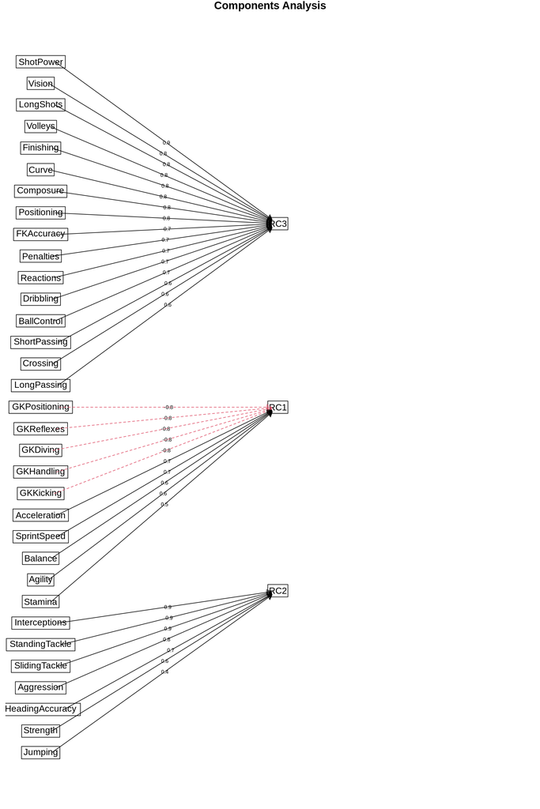

```python
%%R -w 2000 -h 3000 -r 200
fa.diagram(fifa_varimax2)
```

### 행렬도

`-` 아래는 Varimax를 이용하여 나타낸 행렬도이다.

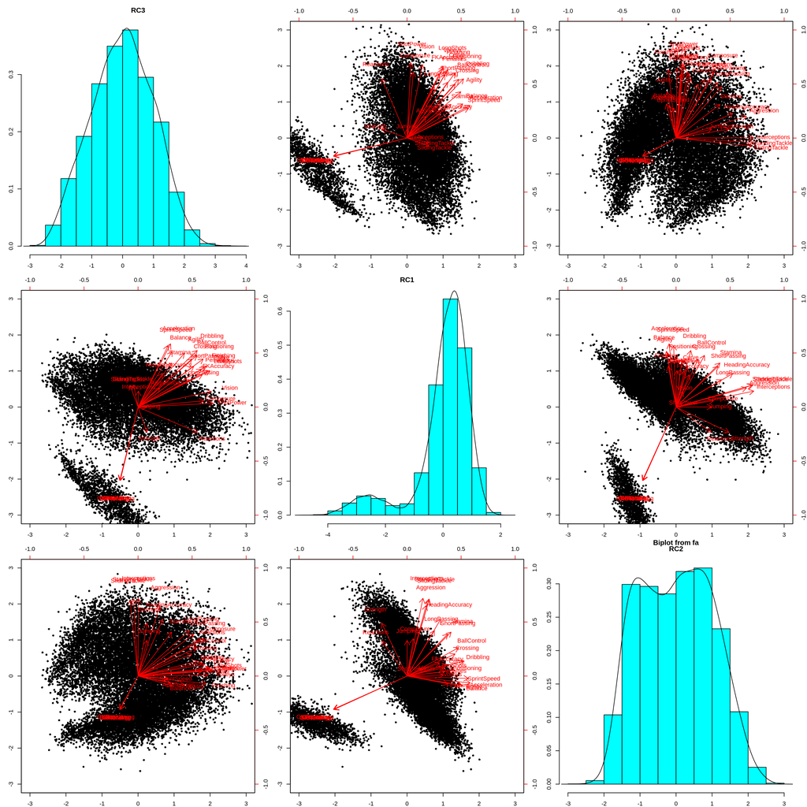

```python
%%R -w 3000 -h 3000 -r 200
biplot(fifa_varimax2,cex=rep(par("cex"), 0.2))
```